# In-Class Computing Task 15

Math 253: Statistical Computing & Machine Learning

Dimension Reduction Methods

In this activity, you’re going to synthesize data from a linear system with multiple inputs and a single output, where only a few of the inputs contribute to the output.

## Overview

A linear system is often written

$${\mathbf Y} = {\mathbf X} \cdot \beta + \epsilon$$

In this notation, $\beta$ are the *coefficients* of the system, ${\mathbf X}$ is the model matrix, and ${\mathbf Y}$ is the output. ${\mathbf Y}$ is not completely set by ${\mathbf X} \cdot {\beta}$, there is some random part to ${\mathbf Y}$, unrelated to any of the columns in ${\mathbf X}$, represented by $\epsilon$.

We are going to make a seemingly strange choice of ${\mathbf X}$: the columns from a matrix representing a monochrome version of the Mona Lisa. This matrix has strong correlations among the columns.

The file is available at `"http://tiny.cc/dcf/mona.rda"` and contains a matrix `mona`. I suggest you first download the file (`download.file()`) to your computer, with `destfile = "mona.rda"`. Do this just once and **don’t** put the `download.file()` command in your `.R` script unless you have commented it out. It is meant to be run only once. In your script, you can load `mona` using `load("mona.rda")`.

You will use the matrix `mona` to form ${\mathbf X}$ in your simulation.

Why use the transpose operator, `t()`? The row-column convention for images are reversed from those for matrices. `t(mona)` gives a matrix with 250 rows and 191 columns.

```r
X <- t(mona) - mean(mona[])
```

The `[]` in `mona[]` means to treat `mona` as one long vector rather than as a matrix.

A matrix can be thought of as a collection of vectors.

Make two more matrices:

1. `X_rand` with has the same size as `X` but consists of iid N($0$,$1^2$) noise.
2. `X_corr` with columns that have the covariance as `X`.

   Remember, you can create correlated noise from iid noise by post-multiplying by the square-root of the desired covariance matrix. That is, post-multiply `Xrand` with `chol(var(X))`.

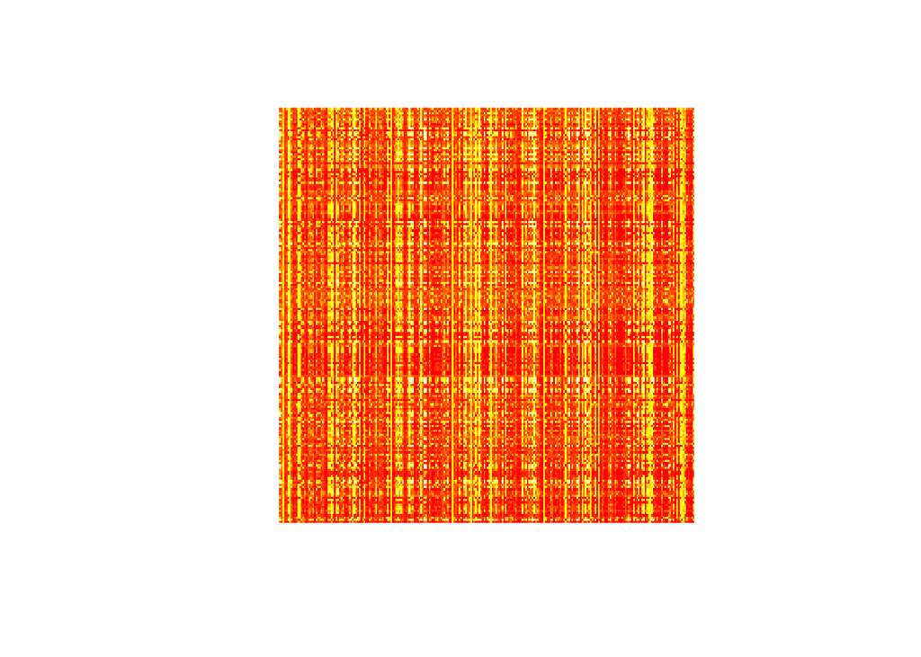

Mona Lisa? Same data as the original, but the order of variables and cases has been randomized.

## Sparse beta

There are 191 columns in each of `X`, `Xrand` and `Xcorr`. Create a vector `beta` that has 191 numbers. Of these 191 numbers, 175 should be 0. The other 16 should have values of 2, 5, $-3$, or $-4$. The order should be random. (Hints: Use these functions `rep()`, `sample(1:191)` as well as indexing.) A vector or matrix consisting mainly of zeros is called *sparse*. The sparse $\beta$ you are using here simulates a system where there are many inter-related variables in ${\mathbf X}$, but just a few of them contribute to the formation of ${\mathbf Y}$

## The output

Create two output vectors based on ${\mathbf X} \cdot {\beta}$, using `X` for ${\mathbf X}$. Each of these output vectors will play the role of $Y$ in the linear system you are simulating.

1. `Y_pure` which is simply ${\mathbf X} \cdot {\beta}$.
2. `Y_real` which is ${\mathbf X} \cdot {\beta}$ plus noise which is iid normal with mean 0 and a variance that is 10% of the variance of `Ypure`.

## Least squares

Use `lm()` to fit `Y_pure` against `X`. Create a vector `beta_hat_pure` to hold the coefficients. Plot `beta_hat_pure` against `beta` and draw a conclusion about the performance of `lm()` in this case.

Remember that your `X` has no vector corresponding to the intercept. Discard the intercept from the coefficients found by `lm()`.

Now do the same for `Y_real`, creating a vector of fitted coefficients `beta_hat_real` and comparing that to your actual `beta`.

Would you be able to detect from `beta_hat_real` that ${\beta}$ is sparse?

## The lasso estimator

Use the lasso method to estimate ${\hat{\beta}}$, which you can store in a vector `beta_lasso`. The `glmnet` package has a command `cv.glmnet()` which uses cross-validation to choose an appropriate value of $\lambda$. The commands look like this:

```r
library(glmnet)
lasso_mod <- cv.glmnet(X, Y_real, alpha=1)
beta_lasso <- predict(lasso_mod, type = "coefficients", s = lasso_mod$lambda.min)
```

## Principal components

Recall that each of the principal components of a matrix has a scalar — called the *singular value* — indicating the “size” of that principal component in contributing to the reconstruction of the matrix. You can find these scalars like this:

```r
sing_vals <- svd(X)$d
```

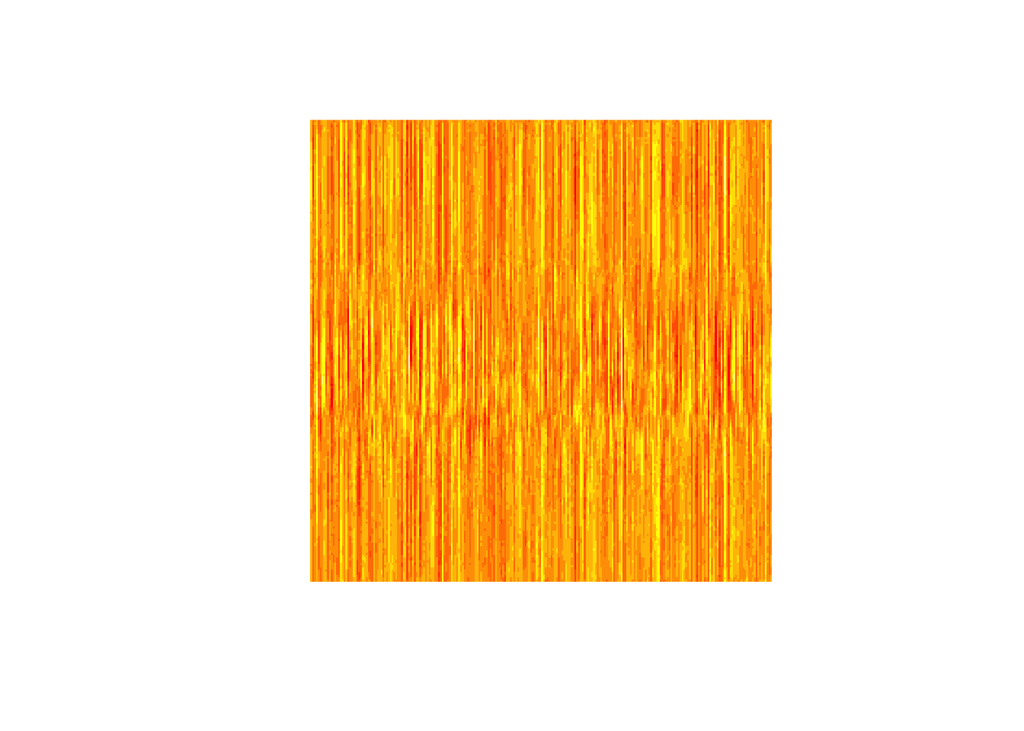

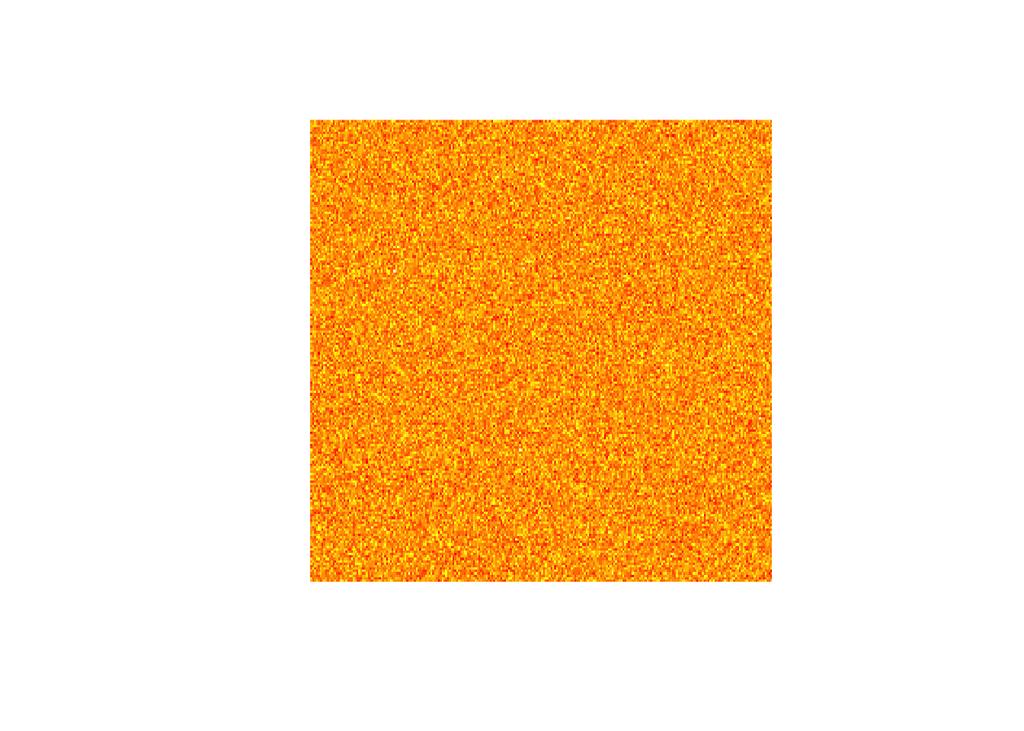

Iid Lisa?

The cumulative sum `cumsum(sing_vals^2)` divided by `sum(sing_vals^2)` produces the $R^2$ of the approximation of `X` using successively $k = 1, 2, 3, ..., 191$ principal components.

Find the singular values of `X_rand` and `X_corr`. On the same graph, plot out $R^2$ versus $k$ for the singular values from each of `X`, `X_rand`, and `X_corr`.

Calculate how many principal components are needed to reconstruct the matrix with an $R^2$ of 99%. Call your answers `n99`, `n99_rand` and `n99_corr` respectively.

```r
library(pls)
pcr.fit <- pcr(Y_real ~ X, scale = TRUE, validation="CV")
```

Using `R2(pcr.fit)`, examine the cross-validated $R^2$ as a function of the number of components used. How many components are needed to get to, say, $R^2 = 0.85$.